# STA 2201H Take-Home Exam Solutions

## Part d

To interpret our model, lets start with looking at the covariate coefficients and group level items and then proceed to visualise. Given the varying slopes structure, we also have interesting correlation/covariance matrices to look at.

Let’s start with the group means and varying slopes. The following table summarizes the coefficient estimates.

```r
ag <- matrix(summary(abmod3)$summary[c(paste0("ag[1,",1:4,"]"),
                                       paste0("ag[2,",1:4,"]"),
                                       paste0("ag[3,",1:4,"]"),
                                       paste0("ag[4,",1:4,"]")), "mean"],
             ncol=4, byrow=TRUE)
rownames(ag) <- levels(airbnb$room_type)
colnames(ag) <- c("Alpha",colnames(zmat3))
kable(ag)
```

|  | Alpha | accommodates | bathrooms | bedrooms |
| --- | --- | --- | --- | --- |
| Entire home/apt | 4.297439 | 0.0592926 | 0.1468411 | 0.1381254 |
| Hotel room | 4.675260 | 0.1435251 | -0.7778740 | 0.1631908 |
| Private room | 3.786035 | 0.1063722 | -0.0356610 | 0.0694784 |
| Shared room | 3.165777 | 0.0546288 | -0.0820886 | 0.1239017 |

The most interesting component of this table is that the slopes of the bathrooms coefficients are negative in all cases other than entire home/apartment. Of all of the groups, we would only expect the entire home/apartment category to have the bathroom number act as a proxy for the size of the house and by extension price. We wouldn’t expect to have say a 5 bathroom hotel room listed. Further, there’s only one hotel room listing with 3 bathrooms, the maximum in this room_type. The limited data may also be playing a part in the negative coefficient. Turning to the group means, they are in line with our general expectations. Staying at a hotel room is more expensive than a personal residence which is then more expensive that just a room. A final interesting observation is that the log price grows with the accommodates number in all cases. This is more interesting when we see that hotel room and private room prices grow the fastest with the capacity. This makes sense in the context of these categories as increasing capacity may involve transitioning from a single room/studio to a suite.

Visually, the accommodates slopes and alpha intercepts can be viewed as follows:

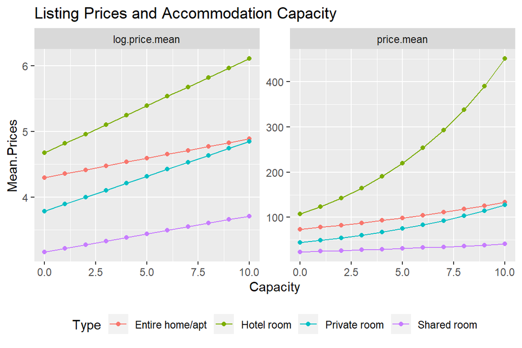

```r
aa <- data.frame(ag[,1:2]) %>%
  mutate(Type = rownames(ag)) %>%
  slice(rep(1:n(), each=11)) %>%
  group_by(Type) %>%
  mutate(Capacity = 0:10) %>%
  ungroup() %>%
  mutate(log.price.mean = Alpha + accommodates*Capacity) %>%
  mutate(price.mean=exp(log.price.mean)) %>%
  pivot_longer(log.price.mean:price.mean, names_to="Category", values_to="Mean.Prices")
aa %>% ggplot(aes(x=Capacity, y=Mean.Prices, colour=Type)) +
  geom_line() +
  geom_point() +
  theme(legend.position="bottom") +
  facet_wrap(~ Category, scales="free") +
  ggtitle("Listing Prices and Accommodation Capacity")
```

The above plot summarises the effects of the capacity of a listing (ie. accommodates) on the mean price and log price. We can see that the rates of change are different and that hotels are just by far the most expensive category, shared rooms are the least expensive and private rooms grow in price faster than entire residences. While a 10 person private room doesn’t happen in reality, the underlying logic is that to find a room that can accommodate more people is more difficult than to add an extra person to a residence where there tends to be more flexibility. Let’s consider the variability by adding a credibility interval around the price.mean values.

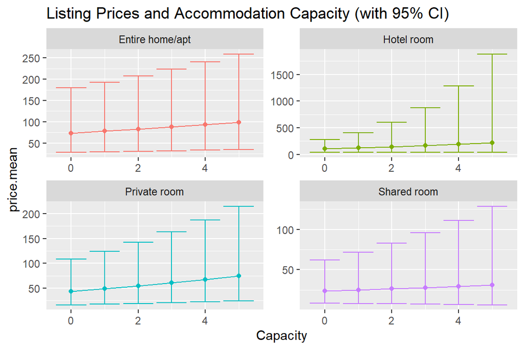

```r
aa2 <- data.frame(ag[,1:2]) %>%
  mutate(Type = rownames(ag)) %>%
  bind_cols(data.frame(Alpha2.5 = summary(abmod3)$summary[paste0("ag[",1:4,",1]"),"2.5%"],
                       Alpha97.5 = summary(abmod3)$summary[paste0("ag[",1:4,",1]"),"97.5%"],
                       Accom2.5 = summary(abmod3)$summary[paste0("ag[",1:4,",2]"),"2.5%"],
                       Accom97.5 = summary(abmod3)$summary[paste0("ag[",1:4,",2]"),"97.5%"])) %>%
  slice(rep(1:n(), each=6)) %>%
  group_by(Type) %>%
  mutate(Capacity = 0:5) %>%
  ungroup() %>%
  mutate(log.price.lower = Alpha2.5 + Accom2.5*Capacity,
         log.price.mean = Alpha + accommodates*Capacity,
         log.price.upper = Alpha97.5 + Accom97.5*Capacity) %>%
  mutate(price.lower=exp(log.price.lower),
         price.mean=exp(log.price.mean),
         price.upper=exp(log.price.upper)) %>%
  select(-log.price.mean, -log.price.lower, -log.price.upper)
aa2 %>% ggplot(aes(x=Capacity, y=price.mean, colour=Type)) +
  geom_line() +
  geom_point() +
  geom_errorbar(aes(ymin=price.lower, ymax=price.upper)) +
  theme(legend.position="none") +
  facet_wrap(~ Type, scales="free") +
  ggtitle("Listing Prices and Accommodation Capacity (with 95% CI)")
```

The above plot illustrates the uncertainty in the model. The points represent the prices computed with the point estimates of the slope of accommodates for each room_type. The error bars compute the same price using the 2.5% and 97.5% quantile values of the accommodates parameters. The error appears so explosive because it is multiplied each time the capacity is increased by 1 and then exponentiated to recover the actual price from the log price. Thus in a model involving log targets, we hope to be comfortable with the values closer to the point estimate.